# feature_extraction

Zongchao Liu

12/21/2019

# * 清洗数据，提取结局变量（这一块先跳过）

```r
outcome_df = read_csv('./data/factors_outcomes.csv') %>%
 rename("name" = "names_eng" ,
        "age" = "年龄",
        "sex" = "性别",
        "group" = "组别（无序分类）",
        "cT" = "cT（有序分类）",
        "cN" = "cN（有序分类）",
        "MRF" = "MRF阳性（二分类）",
        "tumor_length" = "肿瘤长度（连续数值）",
        "tumor_thickness" = "肿瘤厚度（连续数值）",
        "distance" = "治疗前肛缘距离（连续数值）",
        "path" = "活检病理类型（无序分类）",
        "CEA" = "治疗前CEA（连续数值）",
        "differentiation" = "活检分化程度（有序分类）"
        ) %>%
  mutate(name = recode(name,
                       "cengrenyong" = "zengrenyong",
                       "huanghuaxing" = "huanghuaxin",
                       "licaiqun" = "licaiqun2",
                       "lijiabin" = "lijiabing",
                       "wugenghui" = "wugenghui2",
                       "yanpinggen" = "yangpinggen",
                       "yinshaozeng" = "yinshaozhen",
                       "chenqiuru" = "chenqiru"
                       ),
         PCR = factor(PCR),
         differentiation = factor(differentiation),
         sex = recode(sex,
                      "男" = "male",
                      "女" = "female"),
         group = as.character(group),
         cT = factor(cT),
         cN = factor(cN),
         MRF = as.character(MRF),
         path = as.character(path)) %>%
  arrange(name) %>%
  .[15]
```

# 1. 清洗数据，采用的是CTexample的滤波器获取特征

```r
features = read_csv("./data/feature_extracted_2019_1.csv") %>%
  janitor::clean_names() %>%
  mutate(id = c(1:64)) %>%
  select(-x1) %>%
  select(id,everything())

# 挑选出可以用于回归的变量
feature_for_lasso = features[,-c(2:38)]

# 获取观测值姓名信息
file_names = tibble(
  names = list.files("./done")) %>%
  filter(str_detect(names, "-") == FALSE)

# 匹配姓名与CT影像特征数据
feature_for_lasso = cbind(file_names, feature_for_lasso) %>%
  separate(names,c("name","format")) %>%
  select(-format)
```

# see distribution, 查看各个提取特征的数值分布

```r
# center the data
centered_features = scale(feature_for_lasso[,-c(1:2)], scale = T, center = F) %>%
  as.data.frame() %>% cbind(file_names, .) %>%
  separate(names,c("name","format")) %>%
  select(-format)

# load and combine results

centered_features = cbind(outcome_df, centered_features)# this is the data for analysis


skimr::skim(centered_features)
```

```
## Skim summary statistics
##  n obs: 64
##  n variables: 1220
##
## ── Variable type:character ────────────────────────────────────────────────────────────────────────────────────────────
##  variable missing complete  n min max empty n_unique
##      name       0       64 64   5  13     0       64
##
## ── Variable type:factor ───────────────────────────────────────────────────────────────────────────────────────────────
##  variable missing complete  n n_unique          top_counts ordered
##       PCR       0       64 64        2 0: 49, 1: 15, NA: 0   FALSE
##
## ── Variable type:numeric ──────────────────────────────────────────────────────────────────────────────────────────────
##                                                            variable
##                         log_sigma_1_0_mm_3d_firstorder_10percentile
##                         log_sigma_1_0_mm_3d_firstorder_90percentile
##                               log_sigma_1_0_mm_3d_firstorder_energy
##                              log_sigma_1_0_mm_3d_firstorder_entropy
##                  log_sigma_1_0_mm_3d_firstorder_interquartile_range
##                             log_sigma_1_0_mm_3d_firstorder_kurtosis
##                              log_sigma_1_0_mm_3d_firstorder_maximum
##                                 log_sigma_1_0_mm_3d_firstorder_mean
##              log_sigma_1_0_mm_3d_firstorder_mean_absolute_deviation
##                               log_sigma_1_0_mm_3d_firstorder_median
##                              log_sigma_1_0_mm_3d_firstorder_minimum
##                                log_sigma_1_0_mm_3d_firstorder_range
##       log_sigma_1_0_mm_3d_firstorder_robust_mean_absolute_deviation
##                    log_sigma_1_0_mm_3d_firstorder_root_mean_squared
##                             log_sigma_1_0_mm_3d_firstorder_skewness
##                         log_sigma_1_0_mm_3d_firstorder_total_energy
##                           log_sigma_1_0_mm_3d_firstorder_uniformity
##                             log_sigma_1_0_mm_3d_firstorder_variance
##                            log_sigma_1_0_mm_3d_glcm_autocorrelation
##                         log_sigma_1_0_mm_3d_glcm_cluster_prominence
##                              log_sigma_1_0_mm_3d_glcm_cluster_shade
##                           log_sigma_1_0_mm_3d_glcm_cluster_tendency
##                                   log_sigma_1_0_mm_3d_glcm_contrast
##                                log_sigma_1_0_mm_3d_glcm_correlation
##                         log_sigma_1_0_mm_3d_glcm_difference_average
##                         log_sigma_1_0_mm_3d_glcm_difference_entropy
```

[output cut: 3615 more lines]

[output not shown]

# lasso reg for radscores; see distribution of radscores（分为2步，1.用t检验筛选变量，阈值设为0.1，

2. 根据第一步筛选出的变量做lasso’回归）

## 1. 预筛

```r
var_0 = centered_features %>%
  filter(PCR == 0)
var_1 = centered_features %>%
  filter(PCR != 0)
var = colnames(centered_features)[-c(1:2)]


sig_vec = vector()
for (variable in var) {
  print(variable)
  test.sig= t.test(var_0[variable],var_1[variable])$p.value
  sig_vec = append(sig_vec, test.sig)
}
```

[output not shown]

[output cut: 1203 more lines]

```r
sig.total = tibble(
  var = var,
  sig = sig_vec
) %>%
  filter(sig <0.1)

features_into_account = sig.total$var
```

## lasso： 目前暂且未发现结局为0的患者中radscore有正数的

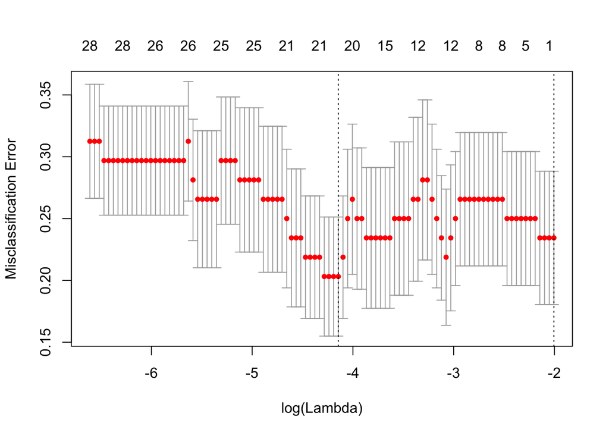

```r
set.seed(1)
outcome = factor(outcome_df$PCR)
predictor_variables = centered_features %>% select(features_into_account) %>% as.matrix()

#10 fold cv for picking lambda
lasso = cv.glmnet(predictor_variables,outcome, family= "binomial",type.measure = "class")
plot(lasso)
```

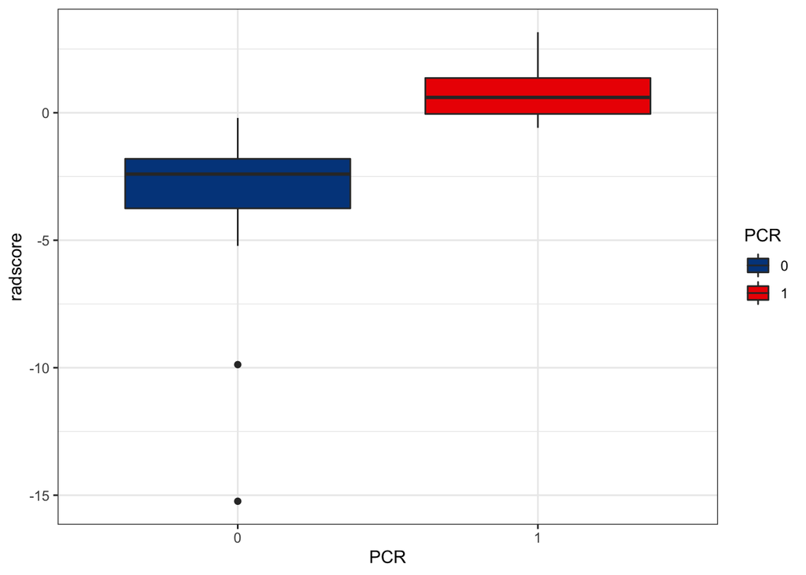

```r
lambda = lasso$lambda.min

lasso_final = glmnet(predictor_variables,outcome, family="binomial",alpha = 1)

lasso_coef = tibble( features = rownames(coef(lasso_final, s = lambda)),
                            coef = as.matrix(coef(lasso_final, s = lambda))) %>%
  filter(coef != 0)
extracted_features = lasso_coef$features

# 矩阵计算radscores
coefs = as.vector(lasso_coef$coef)
a = centered_features %>%
  select(extracted_features[-1]) %>%
  mutate(intercept = seq(1,1,64)) %>%
  select(intercept,everything()) %>%
  as.matrix(.) # a = 特征矩阵

radscores = a %*% coefs

radscore_results = centered_features %>%
  select(PCR,
         name,
         extracted_features[-1]) %>%
  mutate(radscore = radscores,
         name = recode(name,
                       "caimingping" = "caiminping",
                       "lixilai2" = "lixilai")) %>%
  arrange(PCR) %>%
  select(PCR,
         name,
         radscore) %>%
  mutate(id = c(1:64))


# boxplot
radscore_results %>%
  ggplot(aes( x = PCR, y = radscore, fill = PCR)) +
  geom_boxplot() +
  theme_bw() +
  ggsci::scale_fill_lancet()
```

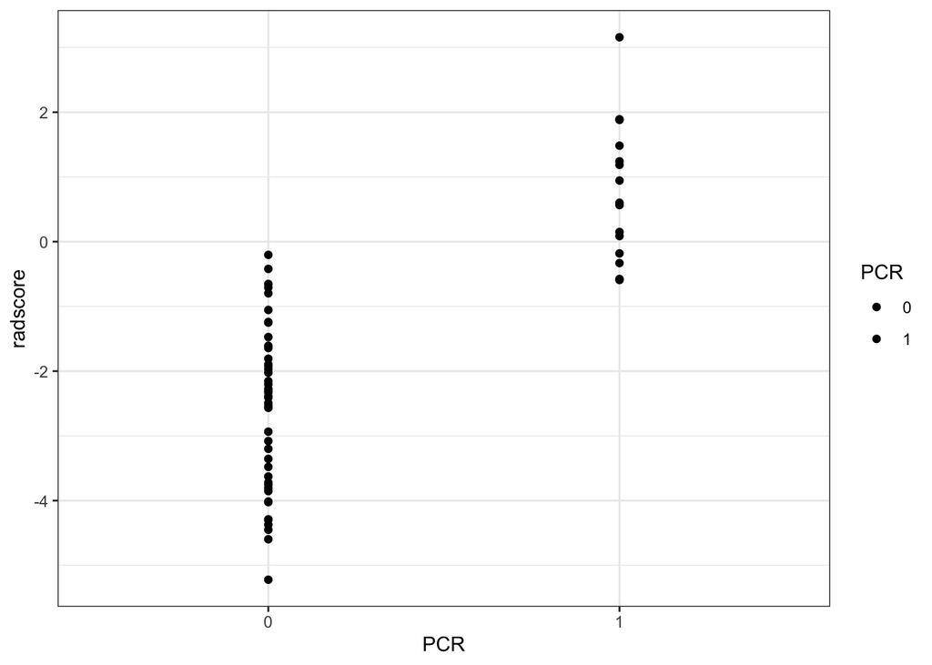

```r
# 散点图
radscore_results %>%
  filter( radscore > (quantile(radscore, .25) - 1.5*IQR(radscore)) & radscore < (quantile(radscore, .75) + 1.5*IQR(radscore))) %>%
  ggplot(aes( x = PCR, y = radscore, fill = PCR)) +
  geom_point() +
  theme_bw() +
  ggsci::scale_fill_lancet()
```

```r
# heatmap 先不用管
# plotting heatmap
## 只看筛选变量
#heatmap = cbind(centered_features, radscore_results$radscore) %>%
#  rename( "radscore" = "radscore_results$radscore" ) %>%
#  select(-pCR, -name) %>%
#  select(extracted_features[-1],radscore) %>%
#  scale() %>%
#  as.data.frame() %>%
#  cbind(pull(centered_features,pCR), pull(centered_features,name), .) %>%
#  mutate(pCR = pull(centered_features,pCR),
#         name = pull(centered_features,name)) %>%
#  select(-1,-2) %>%
#  select(pCR, name, radscore, everything()) %>%
#  arrange(pCR) %>%
#  arrange(radscore) %>%
#  mutate(index = 1:64,
#         index = factor(index)) %>%
#  pivot_longer(4:27, #注意可能会变
#               names_to = "var")
#
###dont run
##heatmap = cbind(centered_features, radscore_results$radscore) %>%
##  rename( "radscore" = "radscore_results$radscore" ) %>%
##  select(-pCR, -name) %>%
##  #select(extracted_features[-1]) %>%
##  scale() %>%
##  as.data.frame() %>%
##  cbind(pull(centered_features,pCR), pull(centered_features,name), .) %>%
##  mutate(pCR = pull(centered_features,pCR),
##         name = pull(centered_features,name)) %>%
##  select(-1,-2) %>%
##  select(pCR, name, radscore,everything()) %>%
##  arrange(pCR) %>%
##  arrange(radscore) %>%
##  select(-1,-2,-3) %>%
##  as.data.frame() %>%
##  mutate(index = 1:64,
##         index = factor(index)) %>%
##  pivot_longer(1:579, #注意可能会变
##               names_to = "var")
####
#
#colors <- colorRampPalette(c("black", "gold"))(10)
#heatmap %>%
#   ggplot(aes(y = var, x = index )) +
#  geom_tile(aes(fill = (value))) +
#  scale_fill_gradientn(colors = colors) +
#  theme_light() +
#  theme(plot.title = element_text(hjust = 0.5)) +
#  geom_vline( xintercept = 50)
```

# logistic reg

## 首先清理数据

```r
combined_data = read_csv('./data/factors_outcomes.csv') %>%
 rename("name" = "names_eng" ,
        "age" = "年龄",
        "sex" = "性别",
        "group" = "组别（无序分类）",
        "cT" = "cT（有序分类）",
        "cN" = "cN（有序分类）",
        "MRF" = "MRF阳性（二分类）",
        "tumor_length" = "肿瘤长度（连续数值）",
        "tumor_thickness" = "肿瘤厚度（连续数值）",
        "distance" = "治疗前肛缘距离（连续数值）",
        "path" = "活检病理类型（无序分类）",
        "CEA" = "治疗前CEA（连续数值）",
        "differentiation" = "活检分化程度（有序分类）"
        ) %>%
  mutate(name = recode(name,
                       "cengrenyong" = "zengrenyong",
                       "huanghuaxing" = "huanghuaxin",
                       "licaiqun" = "licaiqun2",
                       "lijiabin" = "lijiabing",
                       "wugenghui" = "wugenghui2",
                       "yanpinggen" = "yangpinggen",
                       "yinshaozeng" = "yinshaozhen",
                       "chenqiuru" = "chenqiru"
                       ),
         PCR = factor(PCR),
         differentiation = factor(differentiation),
         sex = recode(sex,
                      "男" = "male",
                      "女" = "female"),
         group = as.character(group),
         cT = factor(cT),
         cN = factor(cN),
         MRF = as.character(MRF),
         path = as.character(path)) %>%
 merge(., radscore_results) %>%
 select(name, everything(), - X1) %>%
  select(-2, PCR)
  #select(1,2,3,15,16,17)
 #重新编码变量名，变量类型
```

# 粗略查看总体变量情况

```r
#overall table
library(kableExtra)
library(knitr)
library(arsenal)
control <- arsenal::tableby.control(test = T,
                                    numeric.stats = c("meansd","medianq1q3","range"),
                                    ordered.stats = c("Nmiss"),
                                    digits = 2)
tbl <- arsenal::tableby( PCR ~ ., data = combined_data[,-c(1:2,16)], control = control)

summary(tbl,text = T) %>%
  knitr::kable(booktabs = T, caption = "Descriptive Statistics") %>%
  kable_styling(latex_options = c("striped", "hold_position"))
```

Descriptive Statistics

0 (N=49)

1 (N=15)

Total (N=64)

p value

age

0.716

- Mean (SD)

53.43 (13.48)

52.00 (12.33)

53.09 (13.14)

- Median (Q1, Q3)

57.00 (43.00, 65.00)

50.00 (44.50, 62.50)

55.00 (42.75, 64.00)

- Range

21.00 - 74.00

32.00 - 68.00

21.00 - 74.00

sex

0.842

- female

15 (30.6%)

5 (33.3%)

20 (31.2%)

- male

34 (69.4%)

10 (66.7%)

44 (68.8%)

group

0.018

- 1

14 (28.6%)

2 (13.3%)

16 (25.0%)

- 2

13 (26.5%)

10 (66.7%)

23 (35.9%)

- 3

22 (44.9%)

3 (20.0%)

25 (39.1%)

cT

0.213

- 1

0 (0.0%)

1 (6.7%)

1 (1.6%)

- 2

10 (20.4%)

5 (33.3%)

15 (23.4%)

- 3

9 (18.4%)

3 (20.0%)

12 (18.8%)

- 4

13 (26.5%)

2 (13.3%)

15 (23.4%)

- 5

10 (20.4%)

2 (13.3%)

12 (18.8%)

- 6

5 (10.2%)

0 (0.0%)

5 (7.8%)

- 7

2 (4.1%)

2 (13.3%)

4 (6.2%)

cN

0.251

- 1

9 (18.4%)

2 (13.3%)

11 (17.2%)

- 2

4 (8.2%)

4 (26.7%)

8 (12.5%)

- 3

17 (34.7%)

4 (26.7%)

21 (32.8%)

- 4

1 (2.0%)

1 (6.7%)

2 (3.1%)

- 5

6 (12.2%)

3 (20.0%)

9 (14.1%)

- 6

12 (24.5%)

1 (6.7%)

13 (20.3%)

MRF

0.609

- 0

36 (73.5%)

12 (80.0%)

48 (75.0%)

- 1

13 (26.5%)

3 (20.0%)

16 (25.0%)

tumor_length

0.163

- Mean (SD)

4.27 (1.45)

3.68 (1.25)

4.13 (1.42)

- Median (Q1, Q3)

4.00 (3.30, 4.60)

3.50 (3.00, 3.75)

4.00 (3.15, 4.53)

- Range

2.00 - 8.70

1.40 - 6.50

1.40 - 8.70

tumor_thickness

0.561

- Mean (SD)

15.45 (5.23)

14.60 (3.70)

15.25 (4.90)

- Median (Q1, Q3)

15.00 (12.00, 18.00)

14.00 (12.50, 15.50)

14.50 (12.00, 17.25)

- Range

8.00 - 37.00

9.00 - 22.00

8.00 - 37.00

distance

0.251

- Mean (SD)

6.54 (2.85)

5.59 (2.43)

6.32 (2.77)

- Median (Q1, Q3)

6.50 (4.20, 8.50)

5.50 (3.90, 7.15)

6.25 (3.95, 8.25)

- Range

2.00 - 12.00

2.00 - 10.90

2.00 - 12.00

CEA

0.844

- Mean (SD)

10.55 (22.32)

9.34 (13.72)

10.27 (20.53)

- Median (Q1, Q3)

3.05 (1.79, 5.68)

2.77 (1.37, 10.39)

3.04 (1.76, 6.79)

- Range

0.50 - 110.02

0.50 - 50.97

0.50 - 110.02

path

0.416

- 0

2 (4.1%)

2 (13.3%)

4 (6.2%)

- 1

45 (91.8%)

12 (80.0%)

57 (89.1%)

- 2

1 (2.0%)

0 (0.0%)

1 (1.6%)

- 3

1 (2.0%)

1 (6.7%)

2 (3.1%)

differentiation

0.772

- 0

3 (6.1%)

2 (13.3%)

5 (7.8%)

- 1

18 (36.7%)

4 (26.7%)

22 (34.4%)

- 2

22 (44.9%)

7 (46.7%)

29 (45.3%)

- 3

6 (12.2%)

2 (13.3%)

8 (12.5%)

radscore

< 0.001

- Mean (SD)

-2.98 (2.40)

0.77 (1.06)

-2.10 (2.68)

- Median (Q1, Q3)

-2.41 (-3.75, -1.81)

0.60 (-0.05, 1.36)

-2.09 (-3.39, -0.59)

- Range

-15.24 - -0.20

-0.59 - 3.16

-15.24 - 3.16